# Stablecoins — compare USDC, USDT and DAI transaction sizes and volumes

Rocco Gregori

We want to compare three major Ethereum stablecoins:

- USDC (smart contract address: 0xa0b86991c6218b36c1d19d4a2e9eb0ce3606eb48)
- USDT (smart contract address: 0xdac17f958d2ee523a2206206994597c13d831ec7)
- DAI (smart contract address: 0x6b175474e89094c44da98b954eedeac495271d0f)

We will investigate two questions:

1. How do their transfer sizes differ?
2. How much transfer volume does each stablecoin generate?

Our workflow is:

```
Ethereum
   ↓
Etherscan
   ↓
ERC-20 transfer events
   ↓
R / tidyverse
   ↓
transfer sizes + transfer volumes
```

We use Etherscan to retrieve the already indexed ERC-20 transfer events. Etherscan’s `tokentx` endpoint can be filtered directly by token contract, so we do not need to download unrelated ERC-20 transfers first.

We use the term transfer rather than transaction throughout the lab: one Ethereum transaction can generate several ERC-20 transfer events.

```r
library(tidyverse)
library(httr2)
```

## Download and Cleaning the data

For each token, download its last 10 000 transfers (which is the maximum Etherscan returns).

```r
get_token_transfers <- function(contract,
                                api_key = Sys.getenv("ETHERSCAN_API_KEY"),
                                start_block = 0,
                                end_block = 99999999,
                                offset = 1000) {
  page <- 1
  transfers <- list()

  repeat {
    message("Downloading page ", page, "...")

    response <- request("https://api.etherscan.io/v2/api") |>
      req_url_query(
        chainid = 1,
        module = "account",
        action = "tokentx",
        contractaddress = contract,
        startblock = start_block,
        endblock = end_block,
        page = page,
        offset = offset,
        sort = "desc",
        apikey = api_key
      ) |>
      req_perform() |>
      resp_body_json(simplifyVector = TRUE)

    if (is.character(response$result)) {
      break
    }

    transfers[[page]] <- as_tibble(response$result)

    if (nrow(transfers[[page]]) < offset) {
      break
    }

    if (page == 10) {
      break
    }

    page <- page + 1
  }

  bind_rows(transfers)
}
```

```r
usdc <- get_token_transfers("0xa0b86991c6218b36c1d19d4a2e9eb0ce3606eb48")
usdt <- get_token_transfers("0xdac17f958d2ee523a2206206994597c13d831ec7")
dai  <- get_token_transfers("0x6b175474e89094c44da98b954eedeac495271d0f")

write_csv(bind_rows(usdc, usdt, dai), "stablecoins.csv")
```

```r
transfers <- read_csv("stablecoins.csv")
```

```r
transfers <- transfers |>
  transmute(
    token = tokenSymbol,
    time = as.POSIXct(as.numeric(timeStamp), origin = "1970-01-01", tz = "UTC"),
    hash,
    from,
    to,
    amount = as.numeric(value) / 10^as.numeric(tokenDecimal)
  ) |>
  filter(amount > 0)

count(transfers, token, sort = TRUE)
```

```
## # A tibble: 3 × 2
##   token     n
##   <chr> <int>
## 1 DAI    9732
## 2 USDT   9697
## 3 USDC   9676
```

## 1. Transfer sizes

```r
usdc_stats <- transfers |>
  filter(token == "USDC") |>
  summarise(token = "USDC", n = n(), median = median(amount),
            mean = mean(amount), volume = sum(amount))

usdt_stats <- transfers |>
  filter(token == "USDT") |>
  summarise(token = "USDT", n = n(), median = median(amount),
            mean = mean(amount), volume = sum(amount))

dai_stats <- transfers |>
  filter(token == "DAI") |>
  summarise(token = "DAI", n = n(), median = median(amount),
            mean = mean(amount), volume = sum(amount))

stats <- bind_rows(usdc_stats, usdt_stats, dai_stats)

stats
```

```
## # A tibble: 3 × 5
##   token     n median    mean      volume
##   <chr> <int>  <dbl>   <dbl>       <dbl>
## 1 USDC   9676   302.  57796.  559232680.
## 2 USDT   9697   150.  27359.  265299916.
## 3 DAI    9732  1003. 116757. 1136274903.
```

The mean is much bigger than the median for all three tokens. This means that most transfers are small I use a log scale because the amounts are very skewed:

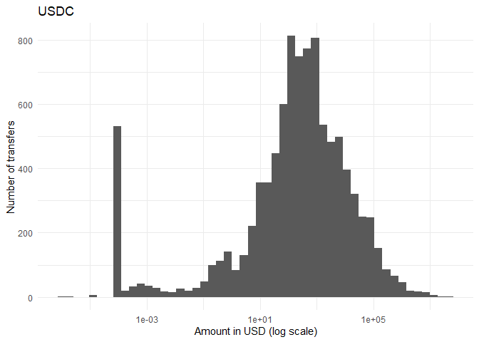

```r
transfers |>
  filter(token == "USDC") |>
  ggplot(aes(amount)) +
  geom_histogram(bins = 50) +
  scale_x_log10() +
  labs(title = "USDC", x = "Amount in USD (log scale)", y = "Number of transfers") +
  theme_minimal()
```

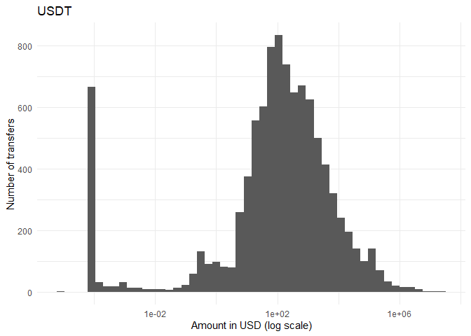

```r
transfers |>
  filter(token == "USDT") |>
  ggplot(aes(amount)) +
  geom_histogram(bins = 50) +
  scale_x_log10() +
  labs(title = "USDT", x = "Amount in USD (log scale)", y = "Number of transfers") +
  theme_minimal()
```

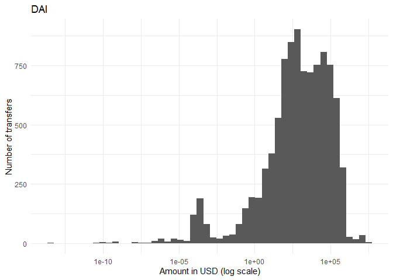

```r
transfers |>
  filter(token == "DAI") |>
  ggplot(aes(amount)) +
  geom_histogram(bins = 50) +
  scale_x_log10() +
  labs(title = "DAI", x = "Amount in USD (log scale)", y = "Number of transfers") +
  theme_minimal()
```

## 2. Transfer volumes

```r
stats |>
  mutate(share = volume / sum(volume)) |>
  select(token, n, volume, share)
```

```
## # A tibble: 3 × 4
##   token     n      volume share
##   <chr> <int>       <dbl> <dbl>
## 1 USDC   9676  559232680. 0.285
## 2 USDT   9697  265299916. 0.135
## 3 DAI    9732 1136274903. 0.579
```